# V11_model_doc

Jinyan Yang

27/05/2020

This file documents the application and modification of the Hufken’s model to PACE.

## Existing issues of V00

Evidently in the V00 model, the growth and plant transpiration both depend on the absolute value of soil moisture while senescence is independent of soil moisture. This lead to difficulty when rooting depth is unknown or varying.

The issue is also related to soil moisture bucket. Since the absolute soil moisture can vary from 0 to say 500 mm, assuming a 50% VWC for 1m soil, the range of growth rate thus can vary a lot. Such a large range makes the fitting inefficient and sometimes impossible. The start values and range of those parameters are also hard to guess since they do not carry clear ecological meanings.

In the original Hufkens model, growth happens as long as growth rate is higher than senesence rate. i.e. growth and senescence can happen at the same time. This leads to issue of fitting par values.

The sensitivity of growth to soil water is assumed to be linear. We know from the plant vulnerability and soil retention curves that the relationship is probably not linear.

The lagged water availability is also questionable. Plants will almost respond on the next day.

## Growth and senescense depend on soil mositure (v11)

We hypothese that plant growth is ralted to carbon allocation and remobilisation. Both processed may not continue for a very long time considering that the water could be depleted soon.

We change the growth to the continuous two days after rainfall. In V00, the growth rate is related to the laged water availibility (i.e., that of 3 days ago), and senescense rate is indepedent of growth. In V11,

Growth changed to:

$$G_{t} = G_{max} f_{T,t} f_{w,t} (1 - {V_{t} \over V_{max}})$$
where FT,t is the temperature modifier, same as in V00.

fw,t is the soil water modifier calculated as below:

$$f_{w,t} = {W_{t} \over (W_{capc} - W_{wilt})}$$
where Wt is the soil moisture at time t; Wcap and Wwilt are soil moisture capacity and wilting point respectively.

Senescense rate change to:
$$S_{t} = S_{max} (1 - f_{w,t})$$

### How does V11 work

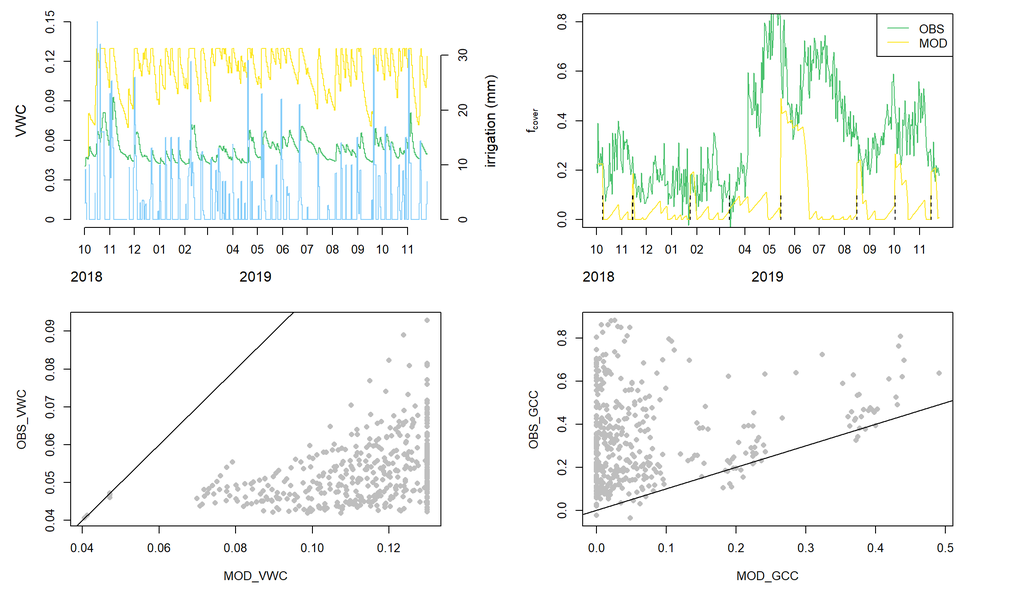

Fig 1. V11 fitted to Luc Ambient Control.

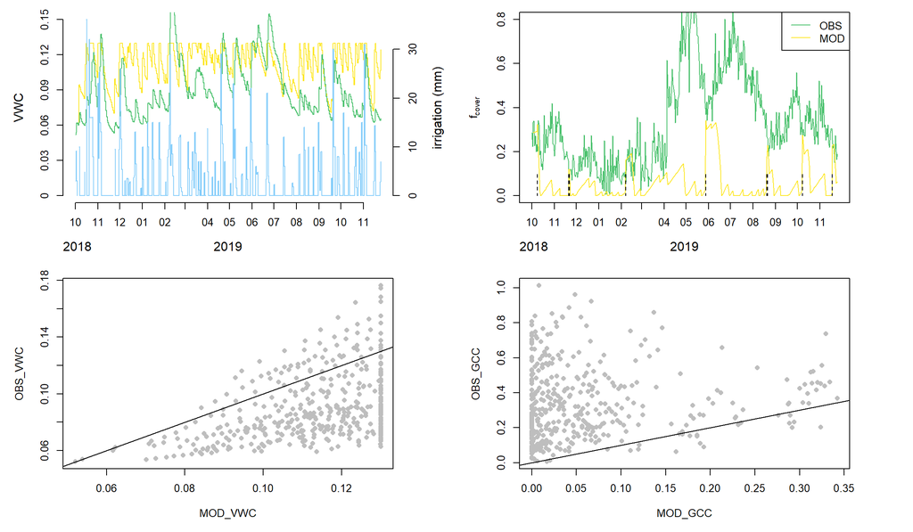

Fig.2. Same thing for FES.

## Known issues of V11

Realistic represetations of baseline phenology for winter and summer active species are missing.

How to allow different species to coexist and compete remains difficult.

The impact of soil water bucket size is still large. With the lack of understanding of that parameter, and its potential variability over time and location, it seems removing the depdence will broaden the application.